# RaukR 2018 Workshop - Machine Learning

Håkon Kaspersen

16 June 2018

## 0.1 What is machine learning?

- Machine learning maps input X to output Y as:

$$Y = f(X)$$

- Machine learning provides two major things:
  - Predicion
  - Feature selection
- Categorized into:
  - Parametric
  - Non-parametric
- Unsupervised learning
  - Data-driven approach
- Supervised learning
  - Hypothesis-driven approach
- Which features are characterisic for the type of cells etc. you want to predict?

### 0.1.1 Main steps of machine learning

- Clean the data: correct, normalize, standardize etc.
- Identify features in the data (deep learning skips this step, it builds its own features)
- Machine learning model is fitted on the training and evaluated on an independent subset

### 0.1.2 How does machine learning work?

- Five steps:
  - Split data set into **train**, **validation** and **test** subsets
    - Randomly assign 70 % to training and 30 % to test (approx.)
  - Fit model in the train subset
  - Validate model on validation subset
  - Repeat steps 1-3 a number of times
  - Test the accuracy of the optimized model on test subset

### 0.1.3 What is a hyperparameter?

- Machine learning design parameters which are set before the learning process starts
  - E.g. the number of covariates to adjust the main variable x of interest for

## 0.2 Random Forest

- Bases predictions on TRUE/FALSE trees
- Makes predictions based on the information given by iterating through the tree

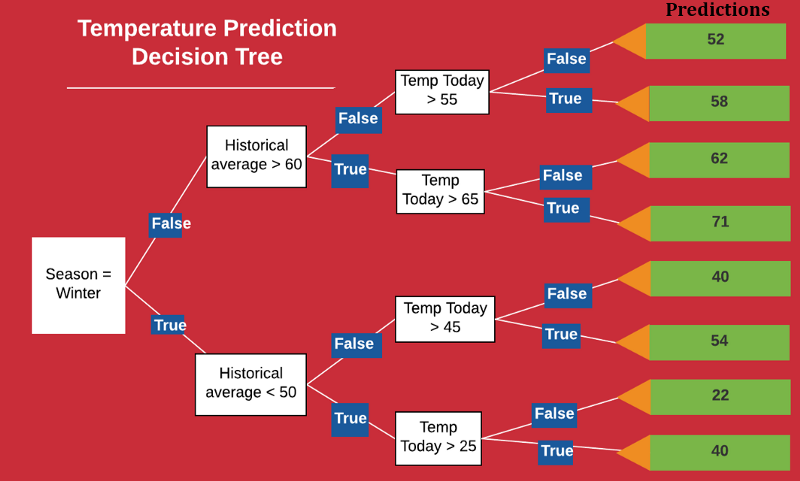

## 0.3 What is Deep Learning?

- Artificial neural networks with multiple layers